# Practical Machine Learning

(weight lifting exercise manner prediction)

Saulius Ces

20/02/2015

#### 1. Brief Introduction

This report describes a process of building an accurate prediction algorithm to predict weight lifting exercise manner using data from accelerometers on the belt, forearm, arm, and dumbell. More information about the dataset can be found here: http://groupware.les.inf.puc-rio.br/har

The main goal of the projct is to build several prediction models, compere them using a cross-validation and choose the most accurate one to predict resuls using the testing dataset.

#### 2. Downloading dataset

```r
#Loading relevant libraries
library(caret)
library(rpart)
library(randomForest)

#Downloading files
training_url  <- "http://d396qusza40orc.cloudfront.net/predmachlearn/pml-training.csv"
testing_url  <- "http://d396qusza40orc.cloudfront.net/predmachlearn/pml-testing.csv"

#Reading files
training  <- read.csv(training_url, na.strings=c("NA",""))
testing  <- read.csv(testing_url, na.strings=c("NA",""))
```

#### 3. Cleaning and preprocessing data

```r
count <- dim(training)[1]*0.8
indices <- which(colSums(is.na(training))>count)
training_new <- training[,-indices]
```

This allowed us to reduce the number of variables down to 60. However, there are also some variables in the dataset that are related to the data collection process (`id`, `user_name`, `new_window` etc.). These variables are irrelevant and might disrupt our prediction model (i.e. some people might almost always do a lifting exercise correct).Therefore, We need to delete them:

```r
#Excluding prediction unrelated variables
bad  <- 1:7
training_new  <- training_new[,-bad]
```

As for the prediction, we might also want to remove variables that are highly correlated with each other. Firstly, they do not provide much additional information. Secondly, including unnecessary variables will make the prediction algorithm to run slower (especially random forests). The benchmark of highly correlated variables is set to 80%.

```r
#Excluding highly correlated variables
cor_matrix  <- cor(training_new[,-53])
hcor  <- findCorrelation(cor_matrix, cutoff = .80, verbose=FALSE)
training_final  <- training_new[,-hcor]
```

#### 4. Choosing a prediction model

While choosing a prediction model several options were considered:

- Prediction with regression
- Prediction with trees
- Prediction with random forests

Predicting factor variables using linear regression models might be tricky. Additionally, they are more useful for modelling and understanding behavior of variables. Therefore, only trees and random forests algorithms were decided to be used for predicting weigh lifting manner.

In order to compare both models and get an expect out-of-sample error rate, we need to perform a cross-validation:

```r
#Cross-validation (Random resampling x30)
n  <- 30
model1_acc  <- vector()
model2_acc  <- vector()
for(i in 1:n){
      inTrain  <- createDataPartition(training$classe, p = 0.7, list=FALSE)
      mytraining  <- training[inTrain,]
      mytesting  <- training[-inTrain,]

      model1 <- rpart(classe ~ ., data=mytraining)
      pred1  <- predict(model1,newdata=mytesting, type="class")
      acc1  <- confusionMatrix(pred1,mytesting$classe)$overall[1]
      model1_acc[i]  <- acc1

      model2 <- randomForest(classe ~. , data=mytraining)
      pred2  <- predict(model2,newdata=mytesting)
      acc2  <- confusionMatrix(pred2,mytesting$classe)$overall[1]
      model2_acc[i]  <- acc2
}
```

We compare two models by plotting histograms of accuracy distributions:

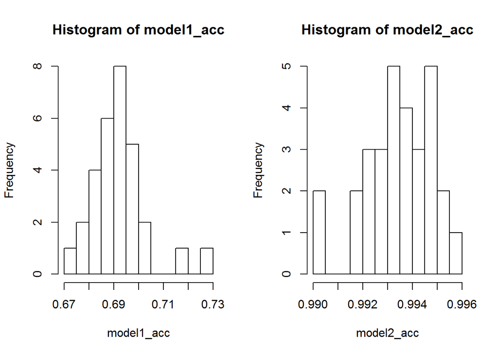

```r
# Plotting histograms of models' accuracy
par(mfrow=c(1,2))
hist(model1_acc,10)
hist(model2_acc,10)
```

```r
#Expected out of sample error for model2
round((1-mean(model2_acc))*100,1)
```

```
## [1] 0.7
```

As can bee seen from both histograms, random forests prediction is less variable and much more accurate than predicting with trees. The expected out of sample error of `model2` is **0.7%**. Therefore, we select `model2` as a final prediction model.

#### 5. Prediction

```r
#Predicting final results
pred_final  <- predict(model2,newdata=testing)

#Saving prediction results
pml_write_files = function(x){
      n = length(x)
      for(i in 1:n){
            filename = paste0("problem_id_",i,".txt")
            write.table(x[i],file=filename,quote=FALSE,row.names=FALSE,col.names=FALSE)
      }
}

#Caling a function to save results
pml_write_files(pred_final)
```